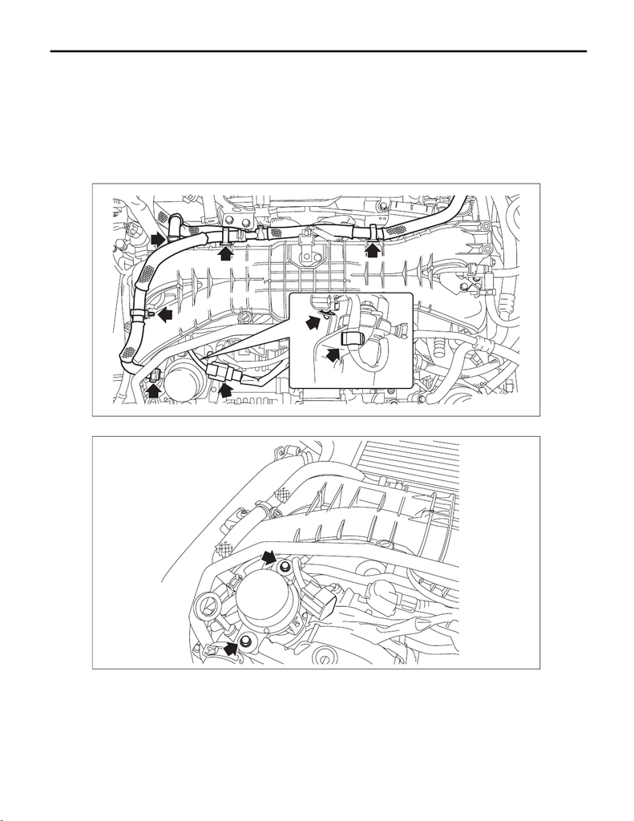

Brake Vacuum Pump

BRAKE

16.Brake Vacuum Pump

A: REMOVAL

NOTE:

Only other models than STI are equipped with the brake vacuum pump.

1) Disconnect the ground terminal from battery sensor. <Ref. to NT-5, BATTERY, NOTE, Note.>

2) Remove the vacuum pump assembly.

(1) Disconnect the connectors of the vacuum pump assembly.

(2) Remove the vacuum hose COMPL.

(3) Remove the bolts, then remove the vacuum pump assembly.

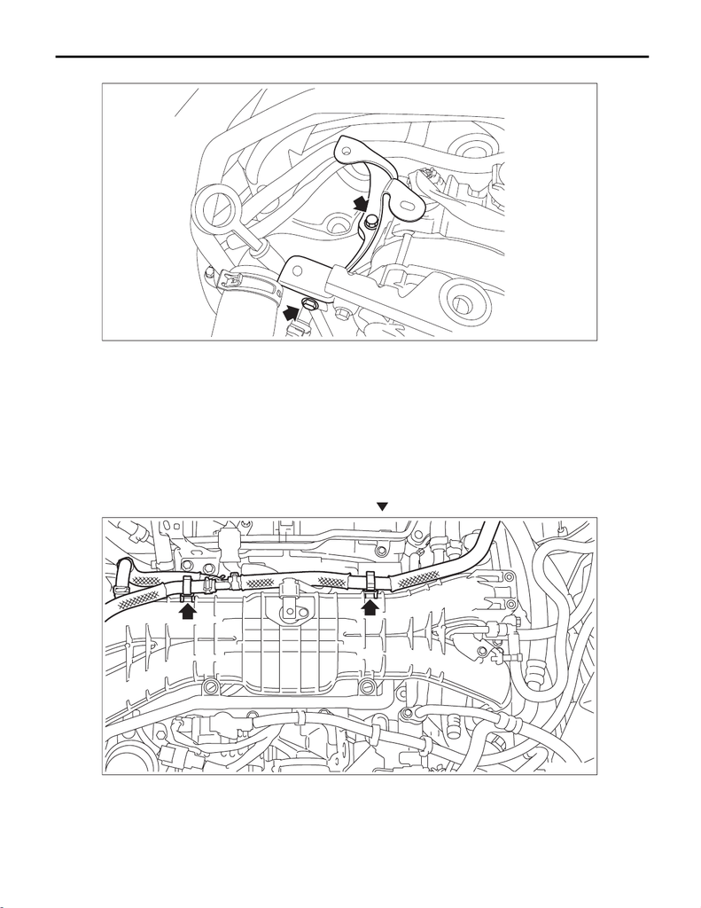

Brake Vacuum Pump

BRAKE

3) Remove the bolts, and then remove the bracket - generator.

B: INSTALLATION

1) Install the bracket - generator.

Tightening torque:

19 N·m (1.9 kgf-m, 14.0 ft-lb)

2) Install the vacuum pump assembly.

Tightening torque:

6.4 N·m (0.7 kgf-m, 4.7 ft-lb)

3) Install the vacuum hose COMPL.

NOTE:

Install the clip to the position (arrowed) of alignment mark of intake manifold.

4) Connect the ground terminal to battery sensor. <Ref. to NT-5, BATTERY, NOTE, Note.>

[figure not shown]

Brake Vacuum Pump

BRAKE

C: INSPECTION

1. BRAKE VACUUM PUMP

OPERATION, Read Diagnostic Trouble Code (DTC).>

2. VACUUM HOSE

Check to see that air only flows in one direction, when air is blown into or sucked from the hose.